# Analisis poblaciones de trucha en León

Santiago Fraga Sáenz

05/06/2024

# 1. ANÁLISIS Y OBSERVACIÓN PREVIA DE LOS DATOS PUBLICADOS POR LA JUNTA DE CASTILLA Y LEÓN

A partir de los datos publicados del seguimiento de las poblaciones piscícolas en las aguas de Castilla Y León, se pretende realizar un análisis de los mismos y comprobar si a partir de ellos se muestran cambios en las variables poblacionales en los años publicados, es decir, desde el año 2014 hasta 2022, último año publicado. Interesa conocer si se ha producido algún cambio en las variables Biomasa, Densidad o Peso Medio, ya que son las variables publicadas o directamente calculadas del resumen de datos divulgado. Es importante señalar que desde la entrada en vigor de la Ley 9/2013, de 3 de diciembre, de pesca de Castilla y León, la gestión de pesca sufre un importante cambio al declararse a la trucha común como especie de interés preferente, implicando que la pesca deberá estar condicionada a la elaboración de planes de gestión y, en el caso de los tramos libres, al no poder controlarse las variables que determinan la tasa de explotación se condiciona la pesca a que esta se haga en la modalidad de sin muerte. Por todo ello procede determinar si la declaración de las aguas libres como libres sin muerte ha supuesto una variación en las variables poblacionales estudiadas.

Preparamos los datos. Antes de comenzar con el análisis mostramos la estructura de los datos una vez tabulados. Estos datos se han extraído de los informes publicados por la Junta de Castilla Y León correspondientes con las redes de vigilancia y seguimineto [link](https://medioambiente.jcyl.es/web/es/caza-pesca/informes-seguimiento-control-poblaciones.html). Se ha creado unn data frame para la provincia de León que comprende las siguientes variables:

```
##       Estacion    Provincia   Gestion     Nivel           año
##  LE-AREC-3:   9   Leon:1413   AREC: 27   1   : 117   2014   :157
##  LE-AREC-7:   9               CCM :153   2   :1287   2015   :157
##  LE001    :   9               CM  :117   NA's:   9   2016   :157
##  LE002    :   9               CSM : 54               2017   :157
##  LE003    :   9               EDS :  9               2018   :157
##  LE004    :   9               L   :972               2019   :157
##  (Other)  :1359               V   : 81               (Other):471
##     Biomasa          Densidad        Peso_medio
##  Min.   : 0.010   Min.   :0.0000   Min.   : 4.50
##  1st Qu.: 3.228   1st Qu.:0.0900   1st Qu.:22.41
##  Median : 5.990   Median :0.1700   Median :36.23
##  Mean   : 7.804   Mean   :0.2393   Mean   :  Inf
##  3rd Qu.:10.805   3rd Qu.:0.3400   3rd Qu.:54.05
##  Max.   :39.200   Max.   :2.0400   Max.   :  Inf
##  NA's   :943      NA's   :945      NA's   :945
```

Las variables Estación, Provincia, Gestión, Nivel y año son de tipo factor y el resto numéricas. Dentro de la gestión diferenciamos los siguientes niveles en función del tramo en el que se situó la estación de muestreo:

L= Tramo libre

CCM= Coto con muerte mixto

V= Vedado

CM= coto con muerte

AREC= Aguas en régimen especial controlado

ARE= Aguas en regimen especial

CSM= Coto sin muerte

Los datos de las variables métricas de las poblaciones de trucha son:

Biomasa; medida en gr/m2

Densidad; medido en indv/m2

Peso medio: Resultado de dividir la biomasa entre la densidad, medida en gr/indv

# 2. ANÁLISIS DE LA VARIABLE BIOMASA

Para dar respuesta a la pregunta que se plantea en esta investigación que no es otra que ver si el cambio normativo introducido por la ley de pesca de 2013 ha supuesto cambios detectables en las variables poblacionales de trucha, tenemos que definir como, en función de los datos existentes, vamos a comprobarlo. Debido a que los datos publicados solo exponen la biomasa y la densidad como únicas variables obtenidas para cada estación, se propone definir un análisis de comparación entre grupos considerando el año 2014 como año de comparación ya que los efectos del cambio de gestión derivados de la nueva ley aún serían incipientes. De los modelos de gestión existentes el posible gran cambio se produciría en los tramos libres ya que pasarían a ser gestionados en el totalidad de las aguas trucheras como libres sin muerte. Observamos en primer lugar la distribución de las variables poblacionales, como variables respuesta, respecto a los grupos anuales y a los sistemas de gestión.

## 2.1 VISUALIZACIÓN DE LOS DATOS

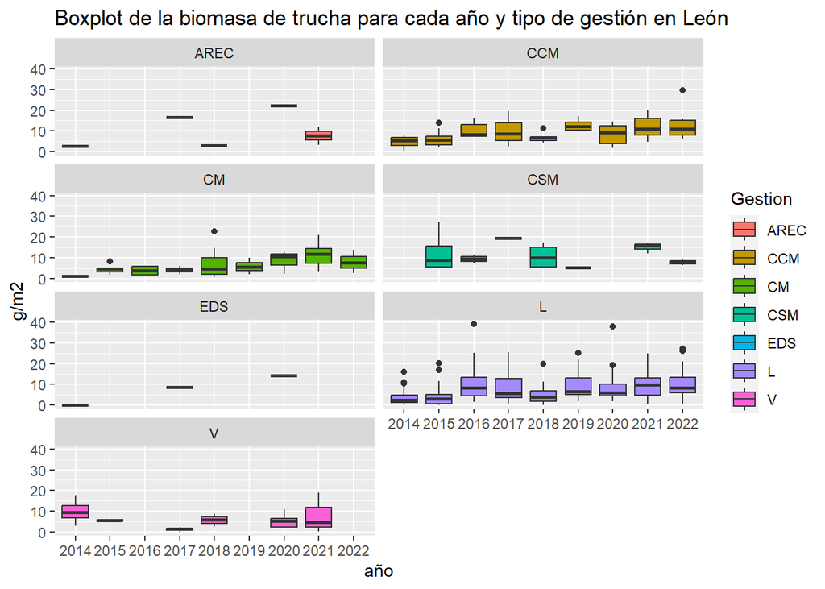

Representamos las variables para los tramos libres, donde es previsible que se puedan observar con los efectos que se quieren comprobar, ya que en ellos la gestión ha pasado de poder sacrificarse las capturas que superasen la talla mínima sin un control de acceso del número de pescadores a ser tramos donde el sacrificio está prohibido, y todo este se produce por primera vez en el año 2014. Por ello este año es el año de referencia con el que se compararán el resto de años para observar si hay cambios significativos en las variables medidas.

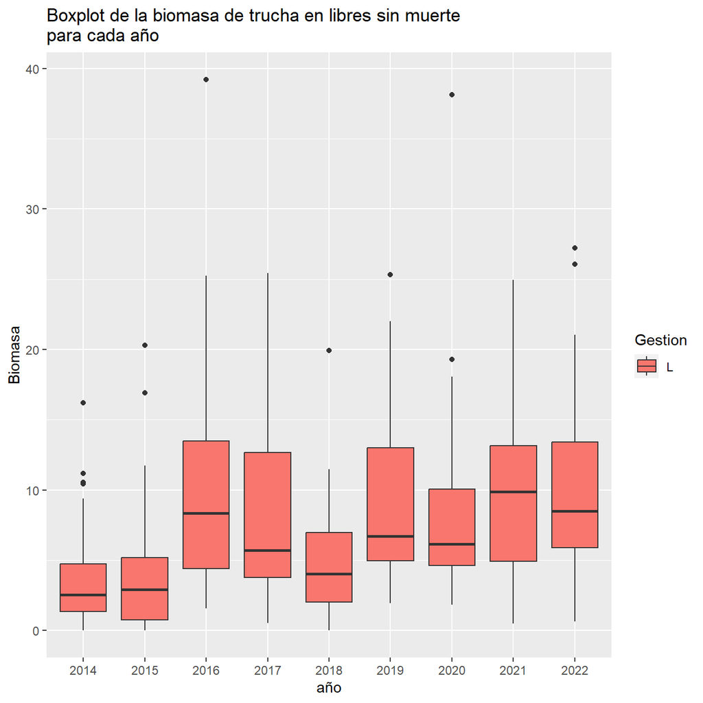

Se observa la existencia de posibles outliers que para la comprobación de las comparaciones y realizar las comprobaciones de hipótesis deberá ser tenida en cuenta para elegir la tecnica estadística. Determinamos a continuación los valores medios para cada año para los tramos de pesca libre, recogiéndose igualmente las desviaciones estandar de cada grupo.

## 2.2 MEDIAS Y DESVIACIONES DE LA VARIABLE BIOMASA

Para los tramos libres de León, comprobamos los valores medias de biomasa de trucha (en gr/m2) en los diferentes años, así como los valores de la desviación estándar.

Valores medios y desviaciones estandar

|  | 2014 | 2015 | 2016 | 2017 | 2018 | 2019 | 2020 | 2021 | 2022 |
| --- | --- | --- | --- | --- | --- | --- | --- | --- | --- |
| Media | 3.670250 | 4.340357 | 10.622222 | 8.507143 | 4.878421 | 9.734091 | 8.015294 | 9.618250 | 10.583044 |
| Desv | 3.675736 | 5.088801 | 9.706981 | 6.800465 | 3.858286 | 6.699002 | 5.917669 | 5.978341 | 7.158117 |

Se observa un aumento de los valores medios respecto a 2014. Representamos la distribución mediante histograma de la variable biomasa

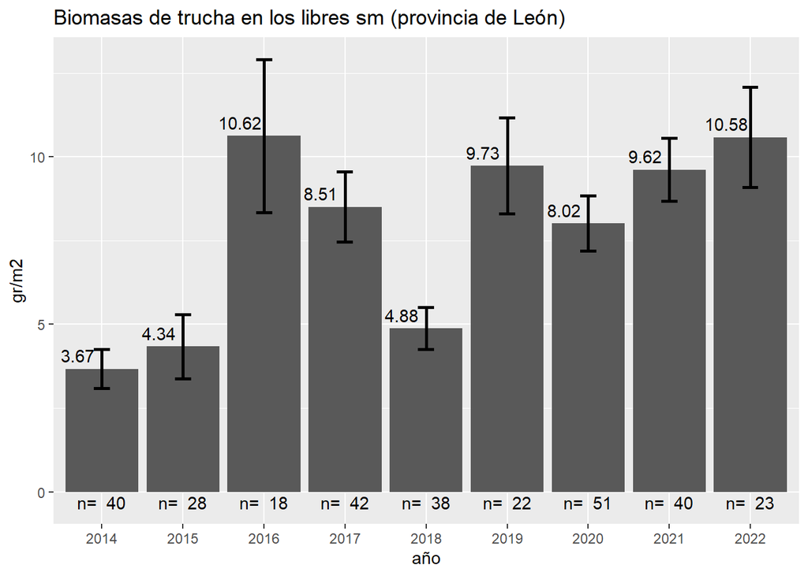

## 2.3 MODELO PARA LA COMPARACIÓN DE LA BIOMASA

Para la comparación de los grupos optamos en primer lugar por observar los datos y ver los supuestos para adaptarlo a un modelo lineal. Comprobamos la normalidad y la homocedasticidad. Primero los visualizamos

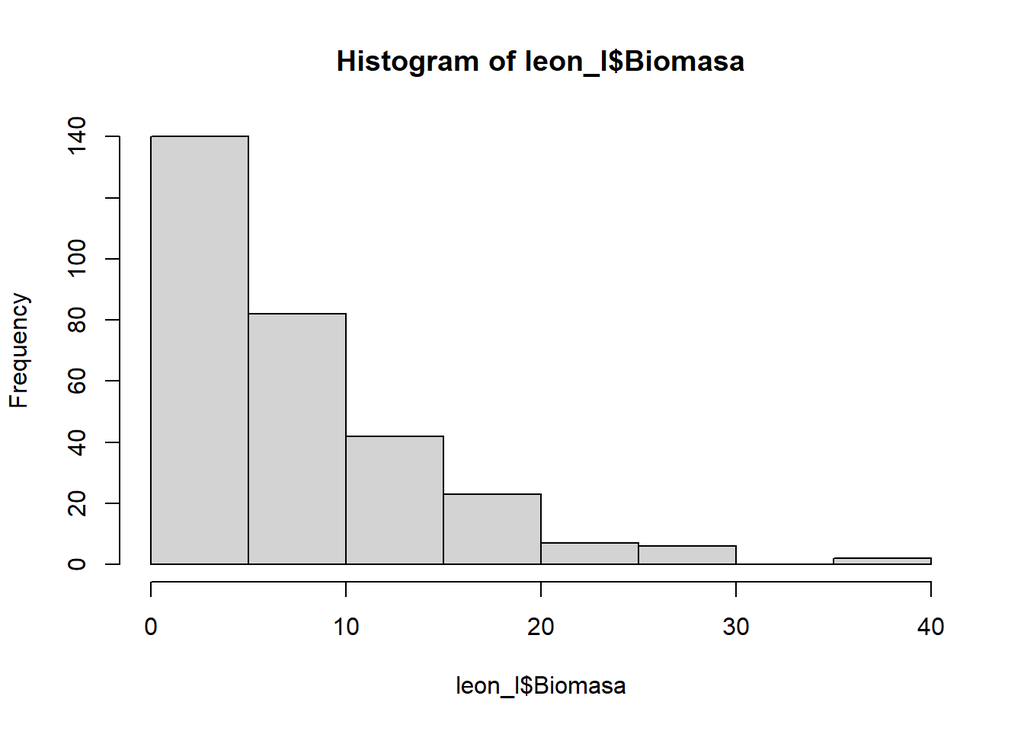

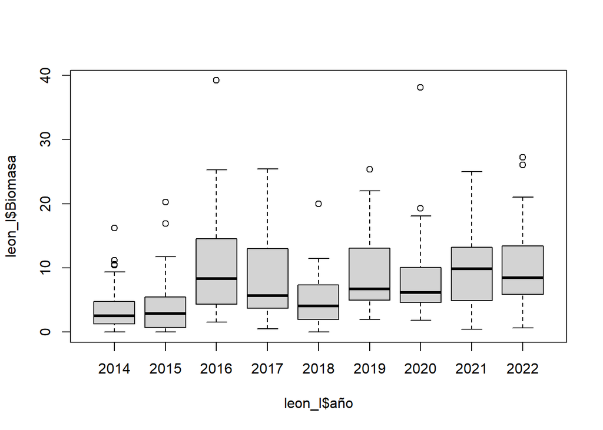

Comprobamos la normalidad y homocedasticidad aunque es visible que no parecen cumplirse ninguno de los 2 criterios

```
##
##  Shapiro-Wilk normality test
##
## data:  leon_tb_l$Biomasa
## W = 0.86002, p-value = 6.96e-16
```

No se puede aceptar la la distribución normal de los datos

```
## Levene's Test for Homogeneity of Variance (center = median)
##        Df F value   Pr(>F)
## group   8  2.7462 0.006158 **
##       293
## ---
## Signif. codes:  0 '***' 0.001 '**' 0.01 '*' 0.05 '.' 0.1 ' ' 1
```

Tampoco se puede aceptar la homocedasticidad de los datos de biomasa para los diferentes años. Por ello es preciso transformar los datos y ver si con ello podemos asumir un modelo lineal. Para ello determinaremos los valores de $\lambda$ mediante la aplicación de una transformación de Box Cox

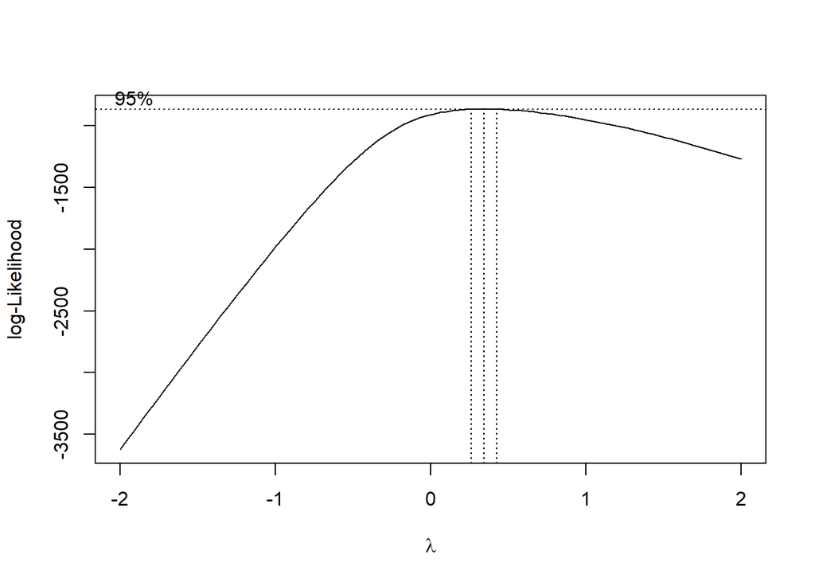

El valor de $\lambda$ obtenido es 0.3434343 es el valor de la potencia usada en la transformación de los datos.

Una vez transformado los datos visualizamos nuevamente

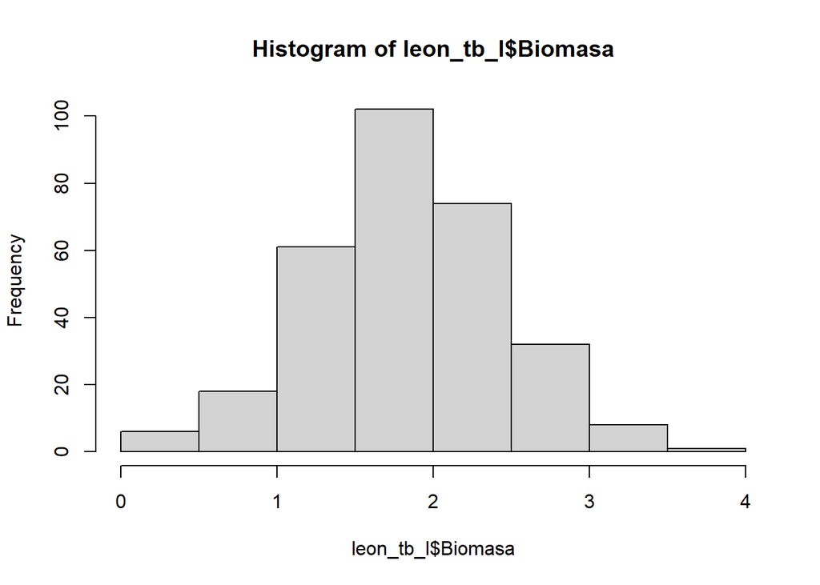

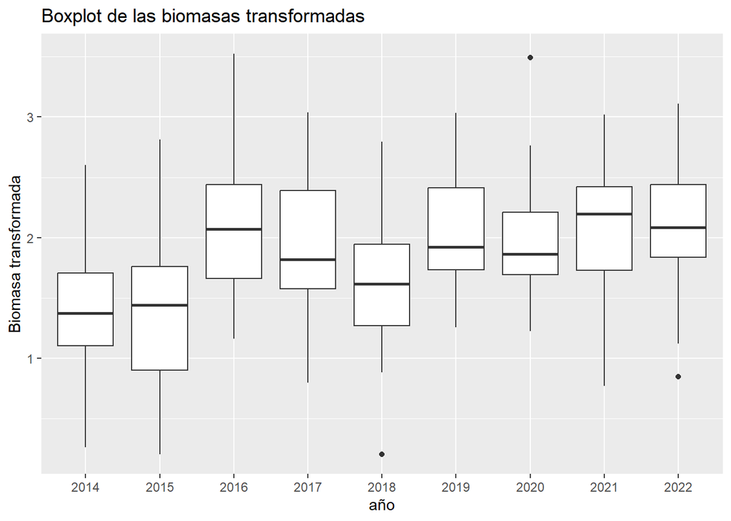

Visualmente ahora parece que los datos pueden cumplir alos criterios de normalidad y homocedasticidad, pese a ello realizamos los test.

```
##
##  Shapiro-Wilk normality test
##
## data:  leon_tb_l$Biomasa
## W = 0.99625, p-value = 0.6955
```

Se acepta la la distribución normal de los datos

```
## Levene's Test for Homogeneity of Variance (center = median)
##        Df F value Pr(>F)
## group   8  1.5076 0.1539
##       293
```

Se acepta la homocedasticidad

Planteamos ahora un modelo lineal mixto. Esto es conveniente en nuestro caso ya que podemos establecer una parte aleatoria del modelo con los datos anidados por la variable Estación. Como término fijo utilizaríamos la variable año, ya que se trata del factor principal que nos explica precisamente si existen diferencias en los valores de la biomasa considerando el año 2014 como el año que se produce el cambio de política de gestión al establecer los libres como libres sin muerte. Para la construcción del modelo seguimos el procedimiento que recomienda Zuur et al. (2009) y que se secuenciaría en fases:

1.Estructura aleatoria óptima. Usando un modelo saturado (beyond optimal model), se determina la estructura óptima del componente aleatorio, la cual no debe contener información que esté en la componente fija. Debemos:

- construir un modelo saturado.
- comparar modelos con distinta estructura aleatoria, mediante máxima verosimilitud restringida (REML).

2.Estructura fija óptima. Una vez encontramos la estructura aleatoria óptima, podemos encontrar la estructura fija óptima. Comparamos los modelos anidados mediante máxima verosimilitud (ML), manteniendo la misma estructura aleatoria.

3.Ajuste del modelo final con REML.

```r
library(nlme)
####PROCEDIMIENTO DE ZUUR PARA LA SELECCION DEL MODELO
##1. Determinamos los efectos variables y para ello saturamos los efectos fijos
leon_tb_l<-leon_tb_l[!is.na(leon_tb_l$Biomasa),]
m1a<-gls(Biomasa~1+año,data=leon_tb_l,method="REML")
m1b<-lme(Biomasa~1+año,random=~1|Estacion,data=leon_tb_l,method="REML")
anova(m1a,m1b)#Efectivamente al año parece afectar a la VD, seleccionamos como variable aleatoria la estación.
```

```
##     Model df      AIC      BIC    logLik   Test  L.Ratio p-value
## m1a     1 10 515.1566 551.9583 -247.5783
## m1b     2 11 441.7112 482.1931 -209.8556 1 vs 2 75.44536  <.0001
```

```r
##2. Seleccionamos las variables de la estructura fija.
m1c<-lme(Biomasa~1,random=~1|Estacion,data=leon_tb_l,method="ML")
m1d<-lme(Biomasa~1+año,random=~1|Estacion,data=leon_tb_l,method="ML")
anova(m1c,m1d)#El modelo m1d es el elegido
```

```
##     Model df      AIC      BIC    logLik   Test  L.Ratio p-value
## m1c     1  3 498.1190 509.2502 -246.0595
## m1d     2 11 412.7164 453.5311 -195.3582 1 vs 2 101.4026  <.0001
```

```r
##3. Ajuste del modelo final con el método REML
m1d_final<-lme(Biomasa~1+año,random=~1|Estacion,method="REML",data=leon_tb_l)
summary(m1d_final)#Diferencias entre 2017 y 2016 respecto de 2014
```

```
## Linear mixed-effects model fit by REML
##   Data: leon_tb_l
##        AIC      BIC    logLik
##   441.7112 482.1931 -209.8556
##
## Random effects:
##  Formula: ~1 | Estacion
##         (Intercept)  Residual
## StdDev:   0.3927698 0.3662552
##
## Fixed effects:  Biomasa ~ 1 + año
##                 Value  Std.Error  DF   t-value p-value
## (Intercept) 1.3559516 0.07892098 186 17.181129  0.0000
## año2015     0.0970936 0.11639828 186  0.834150  0.4053
## año2016     0.5821754 0.13146436 186  4.428389  0.0000
## año2017     0.5128372 0.08178908 186  6.270241  0.0000
## año2018     0.2669033 0.10950051 186  2.437462  0.0157
## año2019     0.6458803 0.12478643 186  5.175886  0.0000
## año2020     0.5535064 0.08103938 186  6.830092  0.0000
## año2021     0.7342029 0.10855404 186  6.763479  0.0000
## año2022     0.7196317 0.12363664 186  5.820538  0.0000
##  Correlation:
##         (Intr) añ2015 añ2016 añ2017 añ2018 añ2019 añ2020 añ2021
## año2015 -0.626
## año2016 -0.536  0.399
## año2017 -0.547  0.382  0.342
## año2018 -0.668  0.656  0.424  0.406
## año2019 -0.566  0.422  0.576  0.361  0.448
## año2020 -0.603  0.414  0.368  0.525  0.441  0.389
## año2021 -0.675  0.661  0.427  0.409  0.707  0.451  0.444
## año2022 -0.573  0.425  0.577  0.364  0.452  0.609  0.392  0.455
##
## Standardized Within-Group Residuals:
##          Min           Q1          Med           Q3          Max
## -2.473325472 -0.547570140  0.007341619  0.563793539  2.603325233
##
## Number of Observations: 302
## Number of Groups: 108
```

El modelo final lo utilizamos patra contrastar los diferentes niveles de la variable predictora, en este caso los diferentes años mediante comparaciones múltiples mediante eltest de Tukey. Comrobamos el modelo de forma gráfica

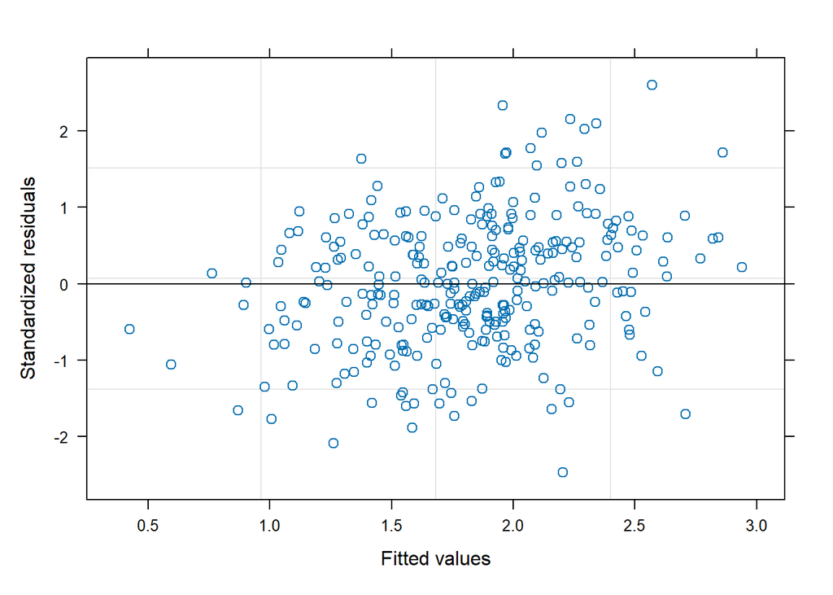

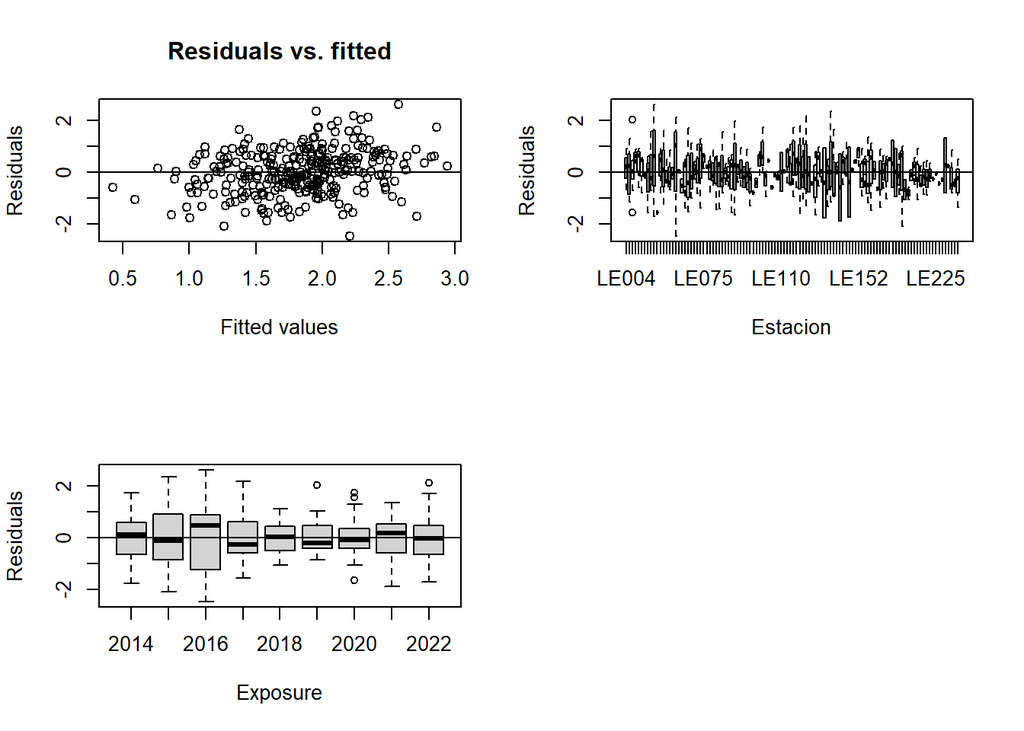

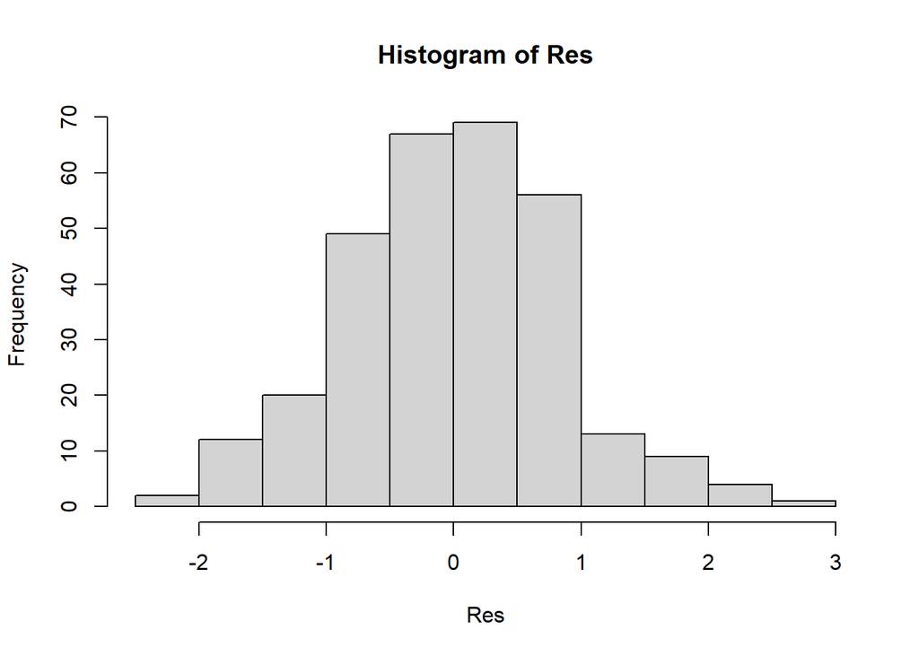

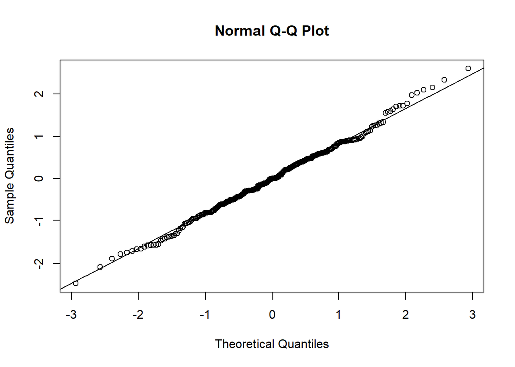

```
##
##   Simultaneous Tests for General Linear Hypotheses
##
## Multiple Comparisons of Means: Tukey Contrasts
##
##
## Fit: lme.formula(fixed = Biomasa ~ 1 + año, data = leon_tb_l, random = ~1 |
##     Estacion, method = "REML")
##
## Linear Hypotheses:
##                  Estimate Std. Error z value Pr(>|z|)
## 2015 - 2014 == 0  0.09709    0.11640   0.834   0.9953
## 2016 - 2014 == 0  0.58218    0.13146   4.428    <0.01 ***
## 2017 - 2014 == 0  0.51284    0.08179   6.270    <0.01 ***
## 2018 - 2014 == 0  0.26690    0.10950   2.437   0.2482
```

[output cut: 35 more lines]

# 2. ANÁLISIS DE LA VARIABLE DENSIDAD

Analizaremos la siguiente variable poblacional que corresponde con densidad de trucha en ind/m2. Como en el caso de la biomasa, interesa conocer la existencia de diferencias significativas derivadas de los diferentes inventarios para ver si el cambio de políticas de gestión que se produce en el año 2013 y que tiene como primer año de implementación el 2014, ha supuesto un cambio en las variables de las poblaciones de trucha. Como en el caso de la biomasa, se escogieron los libres por ser los que más se notaría las medidas implementadas al declararse como de pesca sin muerte. Observamos en primer lugar la distribución de las variables poblacionales, como variables respuesta, respecto a los grupos anuales y a los sistemas de gestión.

## 2.1 VISUALIZACIÓN DE LOS DATOS

```
##     Estacion   Provincia  Gestion Nivel        año         Biomasa
##  LE004  :  9   Leon:972   L:972   1: 45   2014   :108   Min.   : 0.010
##  LE009  :  9                      2:927   2015   :108   1st Qu.: 2.970
##  LE010  :  9                              2016   :108   Median : 5.440
##  LE011  :  9                              2017   :108   Mean   : 7.461
##  LE012  :  9                              2018   :108   3rd Qu.:10.377
##  LE015  :  9                              2019   :108   Max.   :39.200
##  (Other):918                              (Other):324   NA's   :670
##     Densidad        Peso_medio
##  Min.   :0.0000   Min.   : 4.50
##  1st Qu.:0.0800   1st Qu.:21.79
##  Median :0.1600   Median :36.56
##  Mean   :0.2318   Mean   :  Inf
##  3rd Qu.:0.2900   3rd Qu.:53.99
##  Max.   :2.0400   Max.   :  Inf
##  NA's   :671      NA's   :671
```

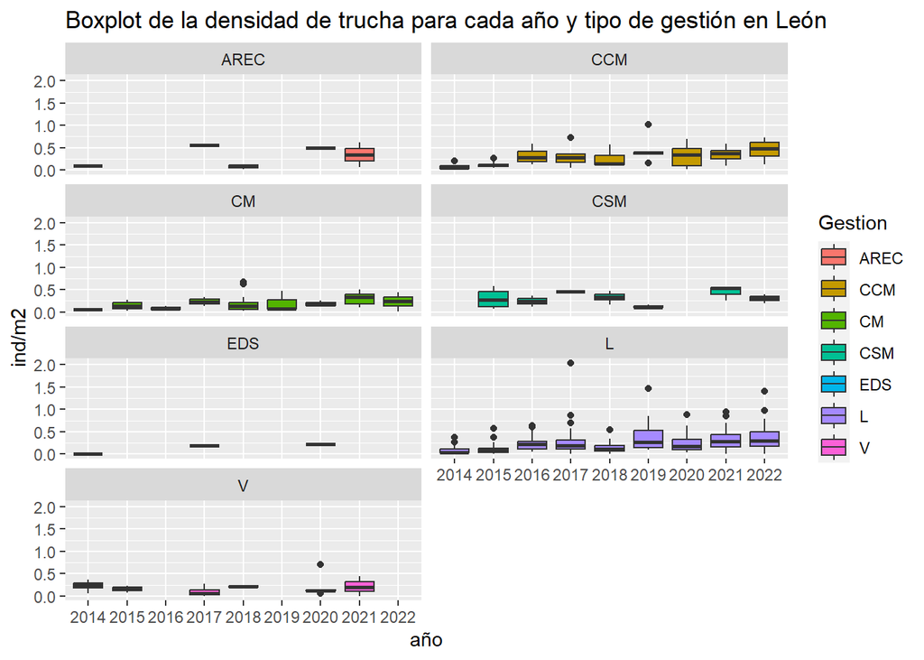

Representamos las variables para los tramos libres, donde es previsible que se puedan observar con los efectos que se quieren comprobar.

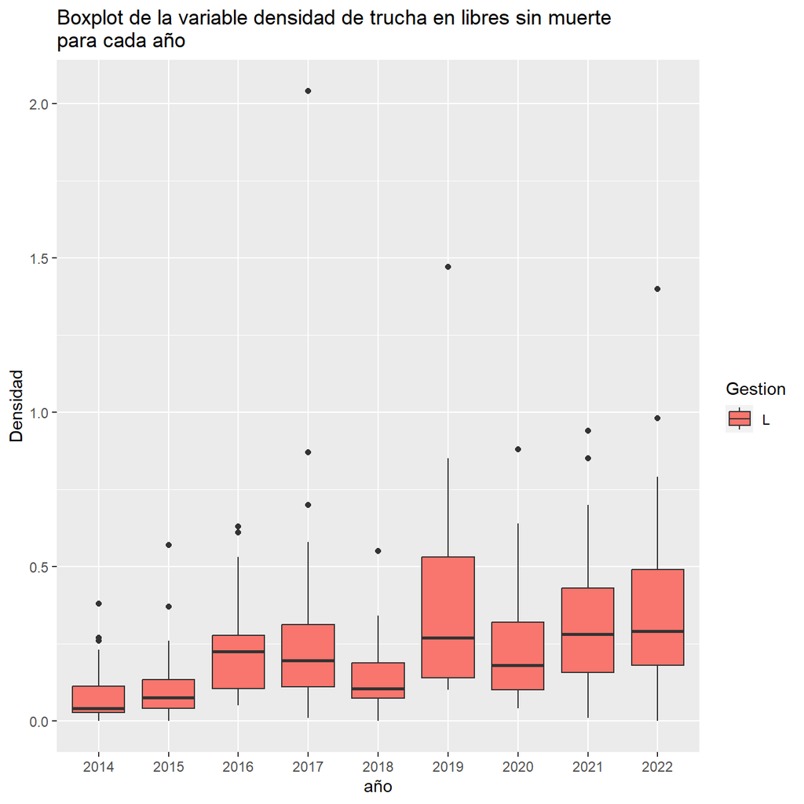

Se observa la existencia de posibles outliers que para la comprobación de las comparaciones y realizar las comprobaciones de hipótesis deberá ser tenida en cuenta para elegir la tecnica estadística. Determinamos a continuación los valores medios para cada año para los tramos de pesca libre, recogiéndose igualmente las desviaciones estandar de cada grupo.

## 2.2 MEDIAS Y DESVIACIONES DE LA VARIABLE DENSIDAD

Para los tramos libres de León, comprobamos los valores medias de biomasa de trucha (en ind/m2) en los diferentes años, así como los valores de la desviación estándar.

Valores medios y desviaciones estandar

|  | 2014 | 2015 | 2016 | 2017 | 2018 | 2019 | 2020 | 2021 | 2022 |
| --- | --- | --- | --- | --- | --- | --- | --- | --- | --- |
| Media | 0.0807500 | 0.1100000 | 0.2438889 | 0.2319512 | 0.1360526 | 0.3780952 | 0.2425490 | 0.3215000 | 0.3991304 |
| Desv | 0.0860944 | 0.1228971 | 0.1788571 | 0.1832378 | 0.1073146 | 0.3298578 | 0.1828753 | 0.2326828 | 0.3182468 |

Se observa un aumento de los valores medios respecto a 2014. Representamos la distribución mediante histograma de la variable densidad

[figure not shown]

## 2.3 MODELO PARA LA COMPARACIÓN DE LA DENSIDAD

Para la comparación de los grupos optamos en primer lugar por observar los datos y ver los supuestos para adaptarlo a un modelo lineal. Comprobamos la normalidad y la homocedasticidad. Primero los visualizamos

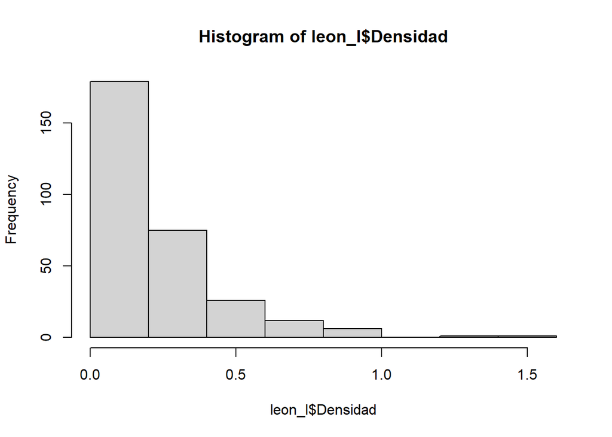

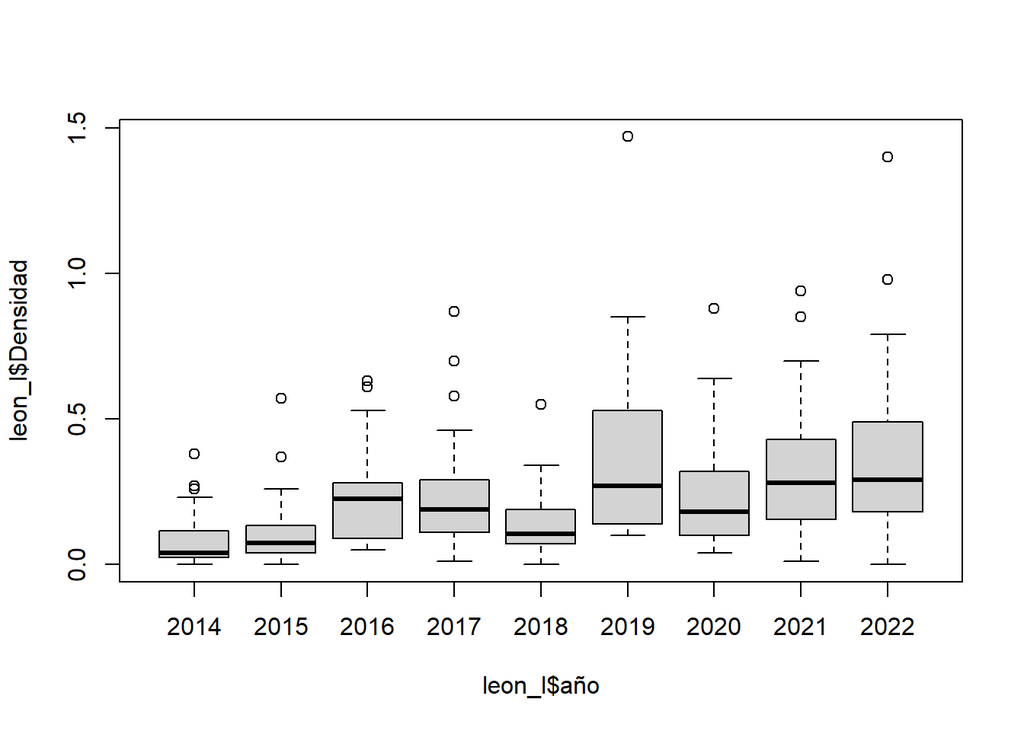

Comprobamos la normalidad y homocedasticidad aunque es visible que no parecen cumplirse ninguno de los 2 criterios

```
##
##  Shapiro-Wilk normality test
##
## data:  leon_l$Densidad
## W = 0.80844, p-value < 2.2e-16
```

No se puede aceptar la la distribución normal de los datos

```
## Levene's Test for Homogeneity of Variance (center = median)
##        Df F value    Pr(>F)
## group   8  5.0933 6.027e-06 ***
##       291
## ---
## Signif. codes:  0 '***' 0.001 '**' 0.01 '*' 0.05 '.' 0.1 ' ' 1
```

Tampoco se puede aceptar la homocedasticidad de los datos de densidad para los diferentes años. Por ello es preciso transformar los datos y ver si con ello podemos asumir un modelo lineal. Para ello determinaremos los valores de $\lambda$ mediante la aplicación de una transformación de Box Cox

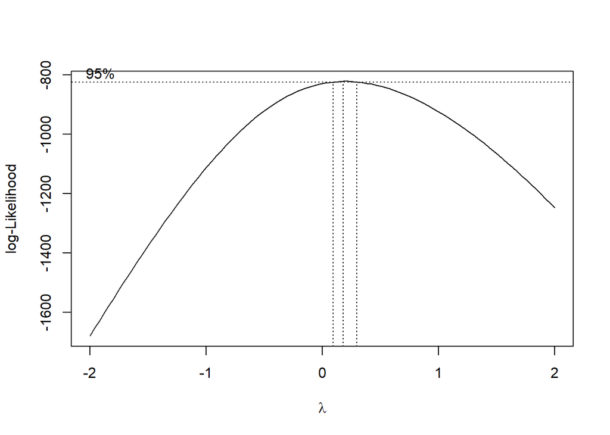

El valor de $\lambda$ obtenido es 0.1818182 es el valor de la potencia usada en la transformación de los datos.

Una vez transformado los datos visualizamos nuevamente

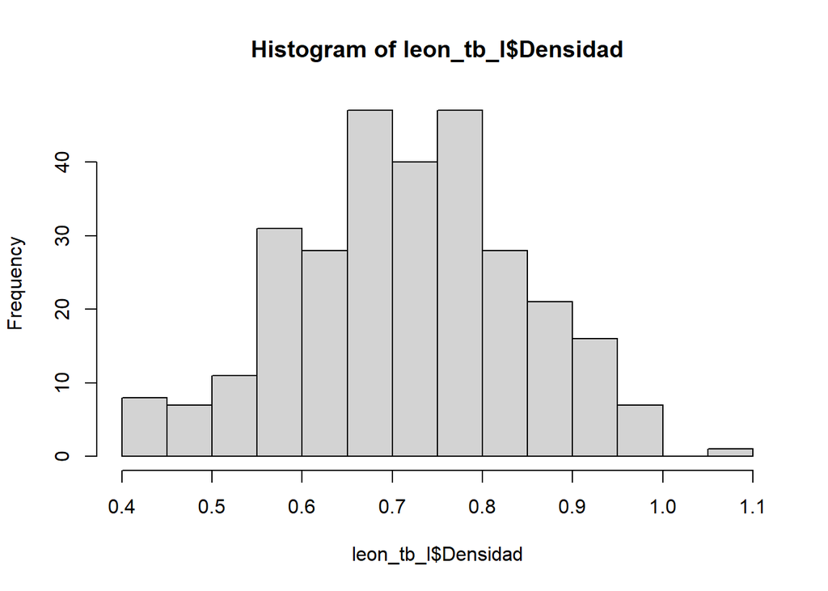

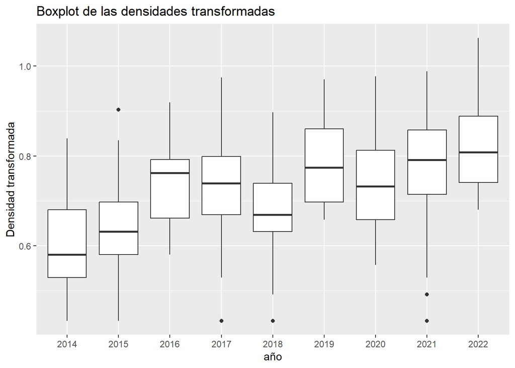

Visualmente ahora parece que los datos pueden cumplir alos criterios de normalidad y homocedasticidad, pese a ello realizamos los test.

```
##
##  Shapiro-Wilk normality test
##
## data:  leon_tb_l$Densidad
## W = 0.99303, p-value = 0.1916
```

Se acepta la la distribución normal de los datos

```
## Levene's Test for Homogeneity of Variance (center = median)
##        Df F value Pr(>F)
## group   8  0.7314 0.6637
##       283
```

Se acepta la homocedasticidad

Planteamos ahora un modelo lineal mixto. Esto es conveniente en nuestro caso ya que podemos establecer una parte aleatoria del modelo con los datos anidados por la variable Estación. Como término fijo utilizaríamos la variable año, ya que se trata del factor principal que nos explica precisamente si existen diferencias en los valores de la densidad considerando el año 2014 como el año que se produce el cambio de política de gestión al establecer los libres como libres sin muerte. Para la construcción del modelo seguimos el procedimiento que recomienda Zuur et al. (2009) y que se secuenciaría en fases:

1.Estructura aleatoria óptima. Usando un modelo saturado (beyond optimal model), se determina la estructura óptima del componente aleatorio, la cual no debe contener información que esté en la componente fija. Debemos:

- construir un modelo saturado.
- comparar modelos con distinta estructura aleatoria, mediante máxima verosimilitud restringida (REML).

2.Estructura fija óptima. Una vez encontramos la estructura aleatoria óptima, podemos encontrar la estructura fija óptima. Comparamos los modelos anidados mediante máxima verosimilitud (ML), manteniendo la misma estructura aleatoria.

3.Ajuste del modelo final con REML.

```r
library(nlme)
####PROCEDIMIENTO DE ZUUR PARA LA SELECCION DEL MODELO
##1. Determinamos los efectos variables y para ello saturamos los efectos fijos
leon_tb_l<-leon_tb_l[!is.na(leon_tb_l$Densidad),]
m1a<-gls(Densidad~1+año,data=leon_tb_l,method="REML")
m1b<-lme(Densidad~1+año,random=~1|Estacion,data=leon_tb_l,method="REML")
anova(m1a,m1b)#Efectivamente al año parece afectar a la VD, seleccionamos como variable aleatoria la estación.
```

```
##     Model df       AIC       BIC   logLik   Test  L.Ratio p-value
## m1a     1 10 -404.3489 -367.8944 212.1744
## m1b     2 11 -456.4216 -416.3217 239.2108 1 vs 2 54.07274  <.0001
```

```r
##2. Seleccionamos las variables de la estructura fija.
m1c<-lme(Densidad~1,random=~1|Estacion,data=leon_tb_l,method="ML")
m1d<-lme(Densidad~1+año,random=~1|Estacion,data=leon_tb_l,method="ML")
anova(m1c,m1d)#El modelo m1d es el elegido
```

```
##     Model df       AIC       BIC   logLik   Test  L.Ratio p-value
## m1c     1  3 -403.5031 -392.4728 204.7515
## m1d     2 11 -513.0900 -472.6457 267.5450 1 vs 2 125.5869  <.0001
```

```r
##3. Ajuste del modelo final con el método REML
m1d_final<-lme(Densidad~1+año,random=~1|Estacion,method="REML",data=leon_tb_l)
summary(m1d_final)#Diferencias entre 2017 y 2016 respecto de 2014
```

```
## Linear mixed-effects model fit by REML
##   Data: leon_tb_l
##         AIC       BIC   logLik
##   -456.4216 -416.3217 239.2108
##
## Random effects:
##  Formula: ~1 | Estacion
##         (Intercept)   Residual
## StdDev:  0.07552165 0.07892997
##
## Fixed effects:  Densidad ~ 1 + año
##                 Value  Std.Error  DF  t-value p-value
## (Intercept) 0.5914992 0.01684741 178 35.10920  0.0000
## año2015     0.0545348 0.02507605 178  2.17478  0.0310
## año2016     0.1302603 0.02798046 178  4.65540  0.0000
## año2017     0.1314597 0.01806762 178  7.27598  0.0000
## año2018     0.0787788 0.02328350 178  3.38346  0.0009
## año2019     0.1826055 0.02729603 178  6.68982  0.0000
## año2020     0.1470773 0.01781654 178  8.25510  0.0000
## año2021     0.1897857 0.02295835 178  8.26652  0.0000
## año2022     0.2192796 0.02650718 178  8.27246  0.0000
##  Correlation:
##         (Intr) añ2015 añ2016 añ2017 añ2018 añ2019 añ2020 añ2021
## año2015 -0.631
## año2016 -0.552  0.398
## año2017 -0.581  0.400  0.360
## año2018 -0.683  0.631  0.429  0.430
## año2019 -0.567  0.407  0.555  0.369  0.439
## año2020 -0.642  0.435  0.390  0.541  0.469  0.400
## año2021 -0.694  0.637  0.434  0.436  0.692  0.444  0.475
## año2022 -0.584  0.422  0.565  0.382  0.454  0.585  0.413  0.459
##
## Standardized Within-Group Residuals:
##          Min           Q1          Med           Q3          Max
## -2.625039224 -0.541821365 -0.003505443  0.615729888  2.302072637
##
## Number of Observations: 292
## Number of Groups: 106
```

El modelo final lo utilizamos patra contrastar los diferentes niveles de la variable predictora, en este caso los diferentes años mediante comparaciones múltiples mediante eltest de Tukey. Comrobamos el modelo de forma gráfica

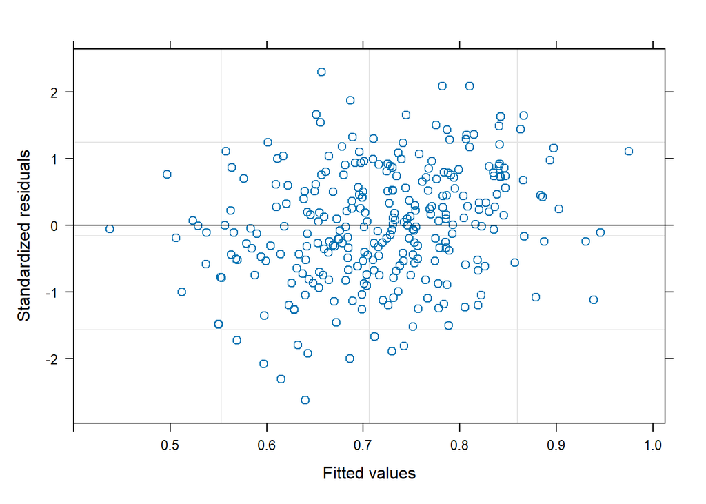

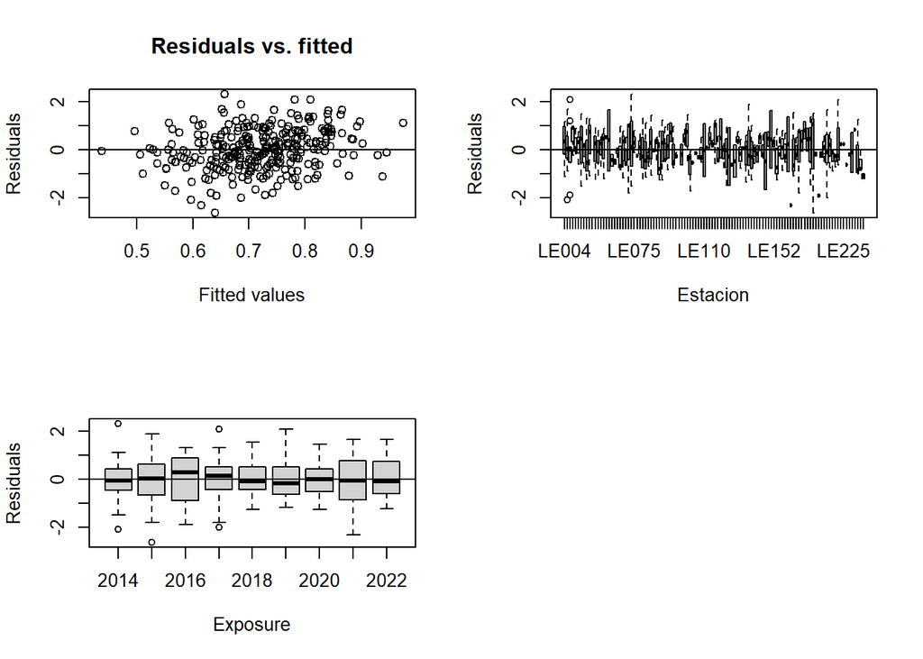

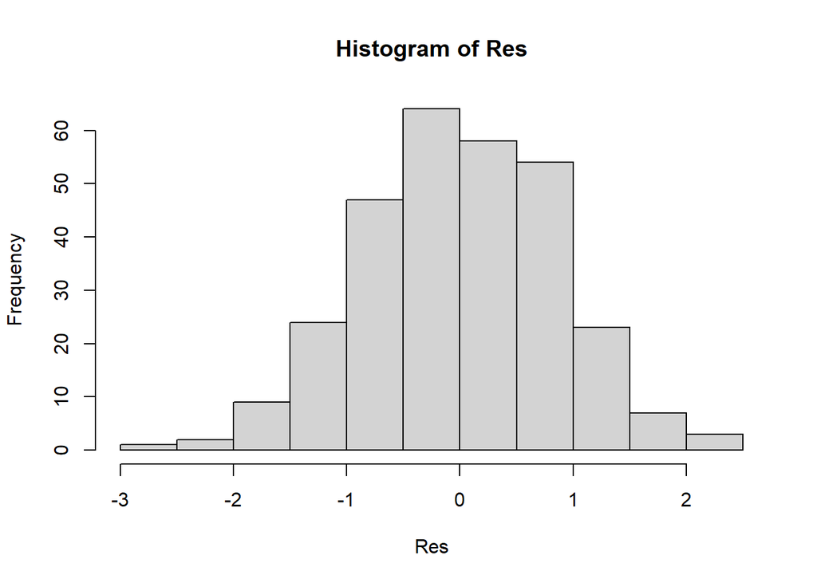

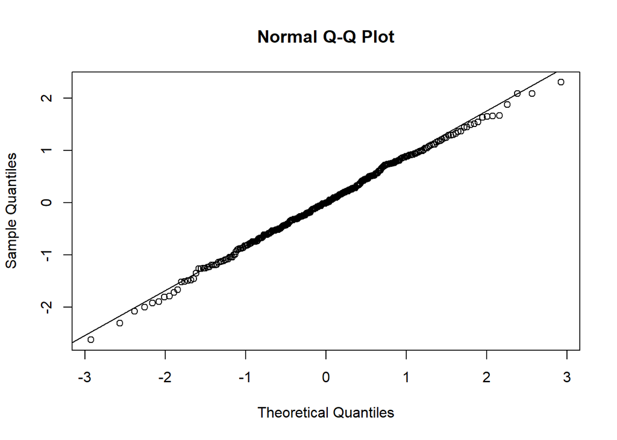

```
##
##   Simultaneous Tests for General Linear Hypotheses
##
## Multiple Comparisons of Means: Tukey Contrasts
##
##
## Fit: lme.formula(fixed = Densidad ~ 1 + año, data = leon_tb_l, random = ~1 |
##     Estacion, method = "REML")
##
## Linear Hypotheses:
##                   Estimate Std. Error z value Pr(>|z|)
## 2015 - 2014 == 0  0.054535   0.025076   2.175   0.4053
## 2016 - 2014 == 0  0.130260   0.027980   4.655    <0.01 ***
## 2017 - 2014 == 0  0.131460   0.018068   7.276    <0.01 ***
## 2018 - 2014 == 0  0.078779   0.023283   3.383   0.0192 *
```

[output cut: 35 more lines]

# 3. ANÁLISIS DE LA VARIABLE PESO MEDIO

Otra variable determinada de las 2 anteriores por simple cocientre entre la biomasa y la densidad es el peso medio (gr/ind). Con ella podemos comprobar si desde 2014 ha habido variaciones significativas en la misma, también centrándonos en los tramos libres, desde la entrada de la normativa que exige la pesca sin muerte.

## 3.1 VISUALIZACIÓN DE LOS DATOS

```
##     Estacion   Provincia  Gestion Nivel        año        Biomasa
##  LE009  :  9   Leon:299   L:299   1: 39   2020   :51   Min.   : 0.010
##  LE010  :  9                      2:260   2017   :41   1st Qu.: 2.970
##  LE004  :  8                              2021   :40   Median : 5.460
##  LE070  :  7                              2014   :39   Mean   : 7.459
##  LE189  :  6                              2018   :38   3rd Qu.:10.365
##  LE011  :  3                              2015   :28   Max.   :39.200
##  (Other):257                              (Other):62
##     Densidad        Peso_medio
##  Min.   :0.0000   Min.   :  4.50
##  1st Qu.:0.0800   1st Qu.: 21.91
##  Median :0.1600   Median : 36.56
##  Mean   :0.2265   Mean   : 44.58
##  3rd Qu.:0.2900   3rd Qu.: 53.96
##  Max.   :1.4700   Max.   :382.00
##
```

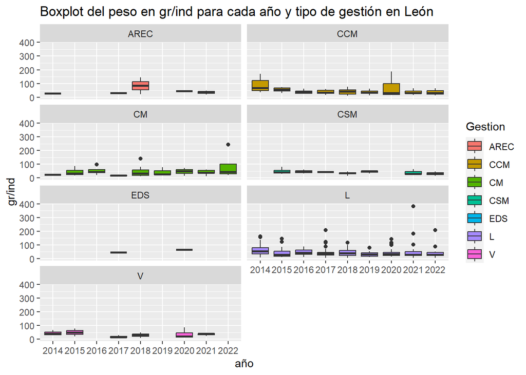

Representamos las variables para los tramos libres, donde es previsible que se puedan observar con los efectos que se quieren comprobar por la introducción de la modalidad de sin muerte de forma general.

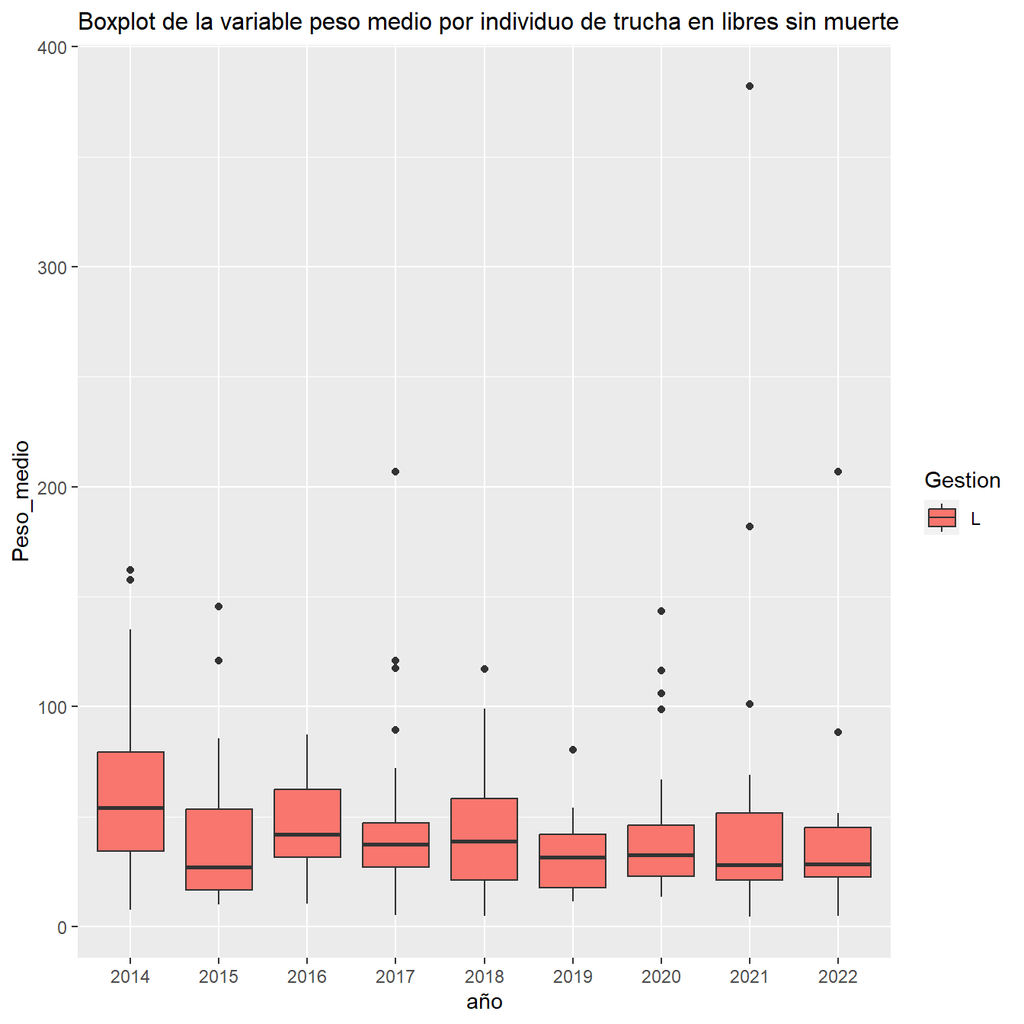

Se observa la existencia de outliers que para la comprobación de las comparaciones y realizar las comprobaciones de hipótesis deberá ser tenida en cuenta para elegir la tecnica estadística. Determinamos a continuación los valores medios para cada año para los tramos de pesca libre, recogiéndose igualmente las desviaciones estandar de cada grupo.

## 3.2 MEDIAS Y DESVIACIONES DE LA VARIABLE PESO MEDIO

Para los tramos libres de León, comprobamos los valores medios del peso medio de trucha (en gr/ind) en los diferentes años, así como los valores de la desviación estándar.

Valores medios y desviaciones estandar

|  | 2014 | 2015 | 2016 | 2017 | 2018 | 2019 | 2020 | 2021 | 2022 |
| --- | --- | --- | --- | --- | --- | --- | --- | --- | --- |
| Media | 60.63667 | 40.66071 | 45.03000 | 44.06390 | 42.72500 | 32.79381 | 41.23627 | 46.91050 | 39.92261 |
| Desv | 37.93280 | 33.46672 | 21.88978 | 35.79717 | 26.25097 | 17.52506 | 26.50332 | 62.37319 | 40.69877 |

[figure not shown]

## 2.3 MODELO PARA LA COMPARACIÓN DEL PESO MEDIO

Para la comparación de los grupos optamos en primer lugar por observar los datos y ver los supuestos para adaptarlo a un modelo lineal. Comprobamos la normalidad y la homocedasticidad. Primero los visualizamos

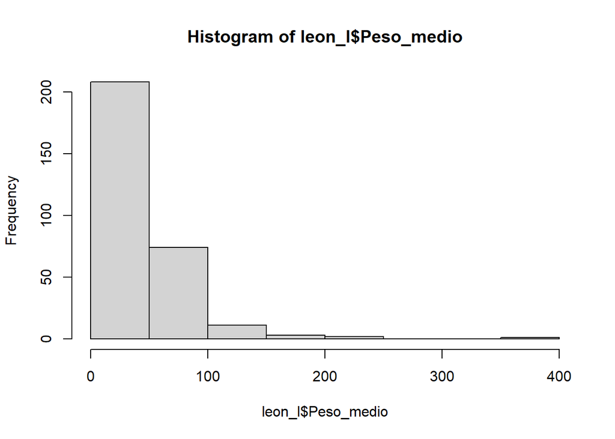

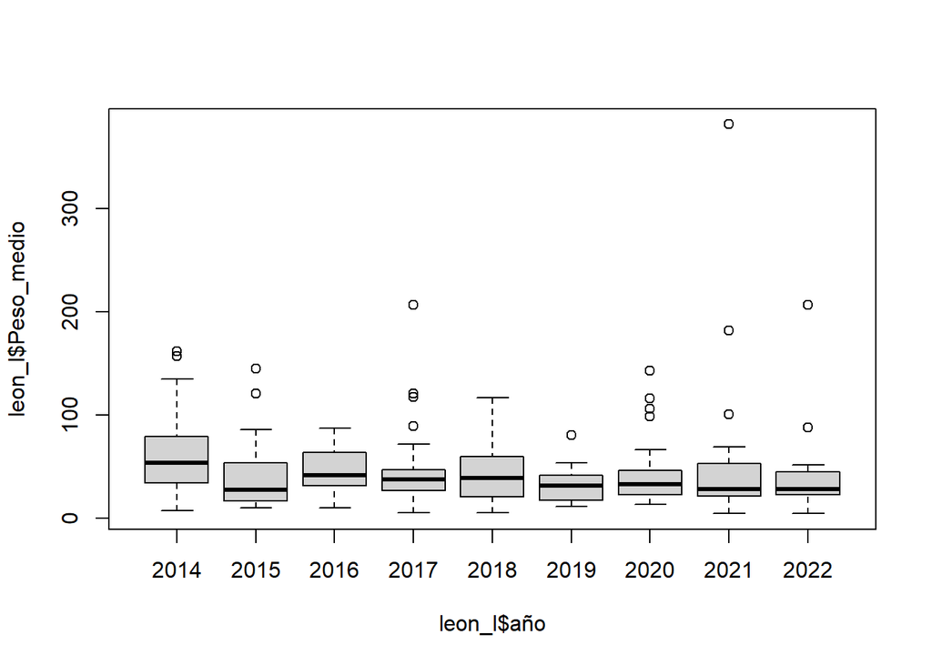

Comprobamos la normalidad y homocedasticidad aunque es visible que no parecen cumplirse ninguno de los 2 criterios

[output not shown]

No se puede aceptar la la distribución normal de los datos

```
## Levene's Test for Homogeneity of Variance (center = median)
##        Df F value   Pr(>F)
## group   8  5.0321 7.27e-06 ***
##       290
## ---
## Signif. codes:  0 '***' 0.001 '**' 0.01 '*' 0.05 '.' 0.1 ' ' 1
```

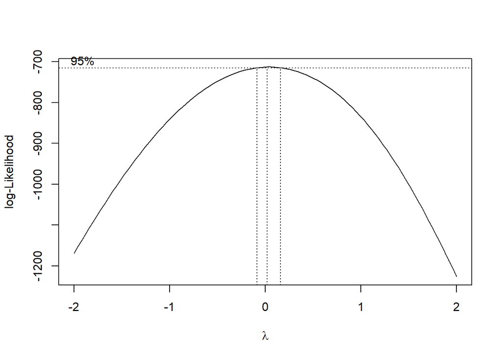

El valor de $\lambda$ obtenido es 0.020202 es el valor de la potencia usada en la transformación de los datos.

Transformamos los datos

Una vez transformado los datos visualizamos nuevamente

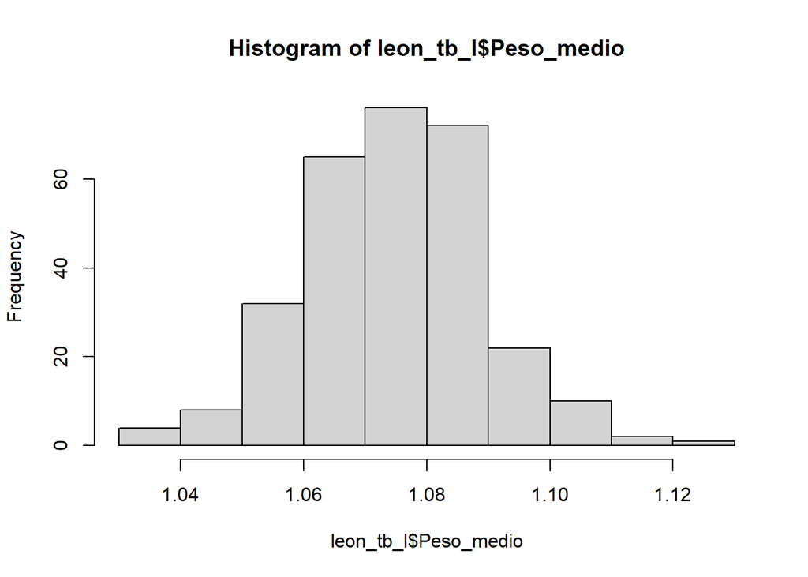

[figure not shown]

Visualmente ahora parece que los datos pueden cumplir alos criterios de normalidad y homocedasticidad, pese a ello realizamos los test.

```
##
##  Shapiro-Wilk normality test
##
## data:  leon_tb_l$Peso_medio
## W = 0.99388, p-value = 0.2858
```

Se acepta la la distribución normal de los datos

```
## Levene's Test for Homogeneity of Variance (center = median)
##        Df F value Pr(>F)
## group   8  0.4542 0.8873
##       283
```

Se acepta la homocedasticidad

- construir un modelo saturado.
- comparar modelos con distinta estructura aleatoria, mediante máxima verosimilitud restringida (REML).

2.Estructura fija óptima. Una vez encontramos la estructura aleatoria óptima, podemos encontrar la estructura fija óptima. Comparamos los modelos anidados mediante máxima verosimilitud (ML), manteniendo la misma estructura aleatoria.

3.Ajuste del modelo final con REML.

```r
library(nlme)
####PROCEDIMIENTO DE ZUUR PARA LA SELECCION DEL MODELO
##1. Determinamos los efectos variables y para ello saturamos los efectos fijos
leon_tb_l<-leon_tb_l[!is.na(leon_tb_l$Peso_medio),]
m1a<-gls(Peso_medio~1+año,data=leon_tb_l,method="REML")
m1b<-lme(Peso_medio~1+año,random=~1|Estacion,data=leon_tb_l,method="REML")
anova(m1a,m1b)#Efectivamente al año parece afectar a la VD, seleccionamos como variable aleatoria la estación.
```

```
##     Model df       AIC       BIC   logLik   Test  L.Ratio p-value
## m1a     1 10 -1544.655 -1508.200 782.3274
## m1b     2 11 -1587.747 -1547.647 804.8735 1 vs 2 45.09227  <.0001
```

```r
##2. Seleccionamos las variables de la estructura fija.
m1c<-lme(Peso_medio~1,random=~1|Estacion,data=leon_tb_l,method="ML")
m1d<-lme(Peso_medio~1+año,random=~1|Estacion,data=leon_tb_l,method="ML")
anova(m1c,m1d)#El modelo m1d es el elegido
```

```
##     Model df       AIC       BIC   logLik   Test  L.Ratio p-value
## m1c     1  3 -1673.773 -1662.743 839.8867
## m1d     2 11 -1680.402 -1639.958 851.2013 1 vs 2 22.62909  0.0039
```